# Chapter 5(Edition Eight): 5.4, 5.5, 5.7, 5.8, 5.22(Hand), 5.23(Hand), 5.26

Jeremy Ling & Emmanuel Mejia

April 10, 2018

```r
library(readxl)     # reading excel files
```

```r
library(reshape2)   # changing tables to long format
library(car)        # qqplot
```

## Problem 5.4

```r
# surface wide format
surface.w <- as.data.frame(x = matrix(data = c(rep(c(.2, .25, .3), each = 3), c(74, 64, 60, 92, 86, 88, 99, 98, 102), c(79, 68, 73, 98, 104, 88, 104, 99, 95), c(82, 88, 92, 99, 108, 95, 108, 110, 99), c(99, 104, 96, 104, 110, 99, 114, 111, 107)), nrow = 9, byrow = FALSE))

names(surface.w) <- c("Feed.Rate", ".15", ".18", ".2", ".25")
```

#### An engineer suspects that the surface finish of a metal part is influenced by the feed rate and the depth of cut. He selects three feed rates and four depths of cut. He then conducts a factorial experiment and obtains the following data:

```r
surface.w
```

```
##   Feed.Rate .15 .18  .2 .25
## 1      0.20  74  79  82  99
## 2      0.20  64  68  88 104
## 3      0.20  60  73  92  96
## 4      0.25  92  98  99 104
## 5      0.25  86 104 108 110
## 6      0.25  88  88  95  99
## 7      0.30  99 104 108 114
## 8      0.30  98  99 110 111
## 9      0.30 102  95  99 107
```

### Part a

#### Analyze the data and draw conclusions. Use $\alpha$ = 0.05.}

We test for the following to determin whether or not feed rate (in/min), depth of cut (in), and the existence of an interaction effect between them using the following hypothesis tests respectively.

$H_0: \tau_1 = ... = \tau_a = 0$

$H_1: \tau_i \ne 0$ at least one

$H_0: \beta_1 = ... = \beta_b = 0$

$H_1: \beta_j \ne 0$ at least one

$H_0: (\tau\beta)_{1 1} = ... = (\tau\beta)_{a b} = 0$

$H_1: (\tau\beta)_{ij} \ne 0$ at least one

```r
#surface <- read_excel("E:/Chapter 5/surface.xlsx")

# surface long format
surface <- melt(data = surface.w, id.vars = c("Feed.Rate"))
names(surface) <- c("Feed.Rate", "Depth", "Surface")
surface
```

```
##    Feed.Rate Depth Surface
## 1       0.20   .15      74
## 2       0.20   .15      64
## 3       0.20   .15      60
## 4       0.25   .15      92
## 5       0.25   .15      86
## 6       0.25   .15      88
## 7       0.30   .15      99
## 8       0.30   .15      98
## 9       0.30   .15     102
## 10      0.20   .18      79
## 11      0.20   .18      68
## 12      0.20   .18      73
## 13      0.25   .18      98
## 14      0.25   .18     104
```

[output cut: 22 more lines]

```r
# a=3
# b=4
# n=3

# running ANOVA
surface.aov = aov(Surface ~ factor(Feed.Rate)*factor(Depth), surface)
summary(surface.aov)
```

```
##                                 Df Sum Sq Mean Sq F value   Pr(>F)
## factor(Feed.Rate)                2 3160.5  1580.2  55.018 1.09e-09 ***
## factor(Depth)                    3 2125.1   708.4  24.663 1.65e-07 ***
## factor(Feed.Rate):factor(Depth)  6  557.1    92.8   3.232    0.018 *
## Residuals                       24  689.3    28.7
## ---
## Signif. codes:  0 '***' 0.001 '**' 0.01 '*' 0.05 '.' 0.1 ' ' 1
```

We analyze the anova and we can see from our p-values that they are all too small. We can state the row, column, and interaction are all significantly different and we can state that this model is significant.

### Part b

#### Prepare appropriate residual plots and comment on the model’s adequacy.

A qqplot of our model, its residuals relative to the fit, and outputs to visualize variance homogeneity and their respective Bartlett Tests are shown below.

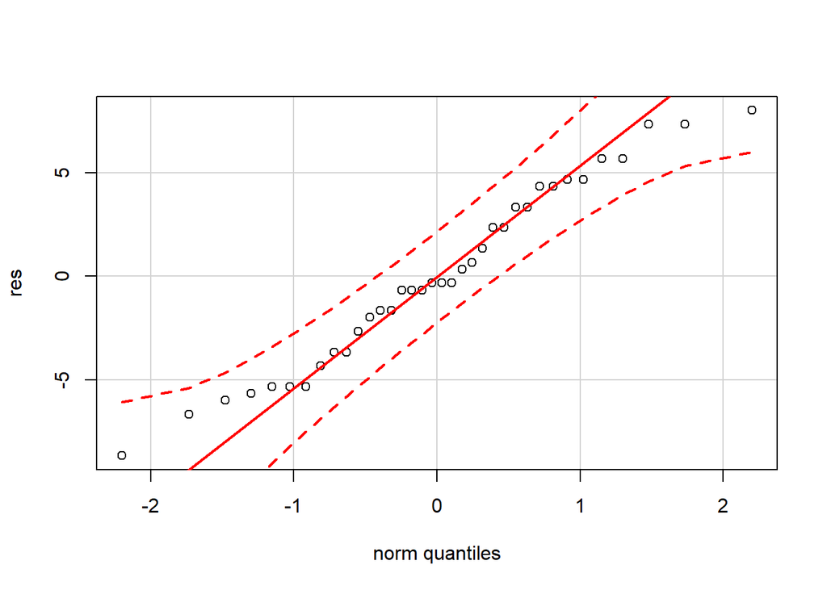

```r
# Baselines: Feed.Rate (.2), Depth (.15)
surface.lm=lm(Surface ~ factor(Feed.Rate)*factor(Depth),surface)
res=surface$Surface-fitted(surface.lm)

# checking normality
qqPlot(res)
```

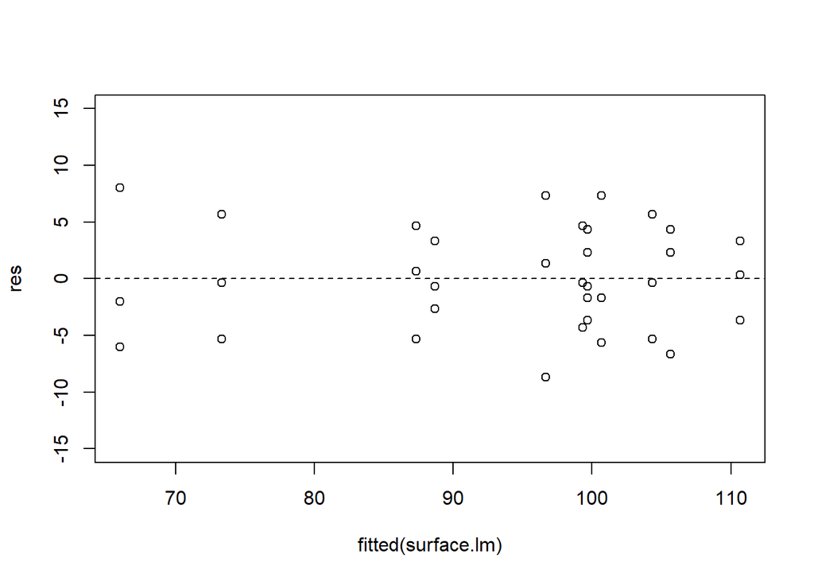

```r
# checking independence
plot(fitted(surface.lm), res, ylim = c(-15,15))
abline(h = 0, lty = 2)
```

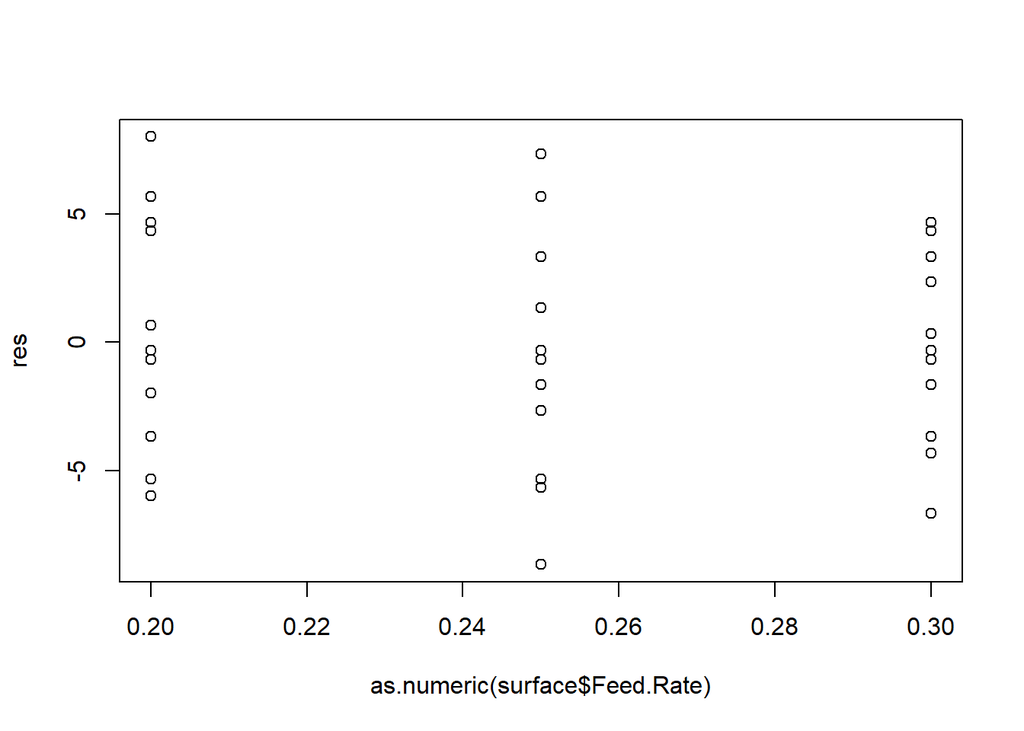

```r
# checking variance homogeneity
plot(as.numeric(surface$Feed.Rate), res)
```

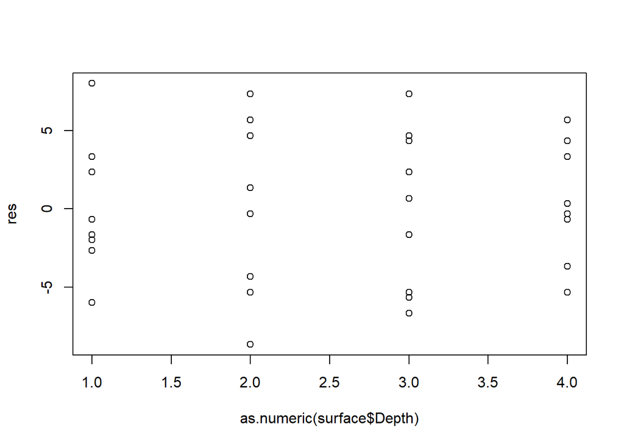

```r
plot(as.numeric(surface$Depth), res)
```

```r
bartlett.test(Surface ~ factor(Feed.Rate), data = surface)
```

```
##
##  Bartlett test of homogeneity of variances
##
## data:  Surface by factor(Feed.Rate)
## Bartlett's K-squared = 8.3141, df = 2, p-value = 0.01565
```

```r
bartlett.test(Surface ~ factor(Depth), data = surface)
```

```
##
##  Bartlett test of homogeneity of variances
##
## data:  Surface by factor(Depth)
## Bartlett's K-squared = 6.544, df = 3, p-value = 0.08794
```

Our qqplot indicates that our model is normal. Our plot of residuals relative to the fit has residuals randomly distributed and centered at zero, indicating the model is independent. Our last two plots indicate that variances seem homogenous, but our Bartlett’s Test indicates that variances in ‘Feed.Rate’ aren’t homogenous.